# ITADATA Hackathon 2024

## Predicting Customer Creditworthiness

Shall we give credit to a bank costumer or not? Given a dataset based on real data the main goal is to categorize the debtors in two groups: one contains trustworthy costumers who are likely to pay their debt off, the other group has instead less reliable costumer. Obviously, with the most performant precision-recall trade-off.

### A first set-up

`Pandas`, `Numpy` and `Matplotlib` are the libraries which are going to get involved in the following exploration, analysis and prediction of the data. Data are contained in the `training.csv` and `test.csv` files.

```python
import pandas as pd
import numpy as np
import matplotlib.pyplot as plt
import seaborn as sns
import statsmodels.api as sm

from imblearn.under_sampling import RandomUnderSampler
from sklearn.preprocessing import StandardScaler
from sklearn.model_selection import train_test_split, cross_val_score
from sklearn.metrics import f1_score, classification_report, confusion_matrix
from sklearn.linear_model import LogisticRegressionCV
from sklearn.neighbors import KNeighborsClassifier
from sklearn.ensemble import RandomForestClassifier
from sklearn.svm import LinearSVC
```

```python
train = pd.read_csv("training.csv")
test = pd.read_csv("test.csv")
```

```python
cols = train.columns
train[cols[:18]].describe()
```

|  | client_id | product8 | product10 | product13 | product12 | product11 | product4 | product17 | product2 | product3 | product1 | product7 | product6 | product5 | product14 | product15 | product16 | product9 |
| --- | --- | --- | --- | --- | --- | --- | --- | --- | --- | --- | --- | --- | --- | --- | --- | --- | --- | --- |
| count | 2.056160e+06 | 2.056160e+06 | 2.056160e+06 | 2.056160e+06 | 2.056160e+06 | 2.056160e+06 | 2.056160e+06 | 2.056160e+06 | 2.056160e+06 | 2.056160e+06 | 2.056160e+06 | 2.056160e+06 | 2.056160e+06 | 2.056160e+06 | 2.056160e+06 | 2.056160e+06 | 2.056160e+06 | 2.056160e+06 |
| mean | 5.173345e+04 | 2.386609e-01 | 2.843013e-01 | 2.253502e-01 | 2.000948e-01 | 2.254596e-01 | 2.029195e-01 | 2.848319e-01 | 4.942354e-01 | 5.005564e-01 | 3.056338e-01 | 2.057568e-01 | 2.306109e-01 | 2.025708e-01 | 2.026224e-01 | 4.072699e-01 | 1.999825e-01 | 3.214604e-01 |
| std | 2.983887e+04 | 4.262651e-01 | 4.510811e-01 | 4.178128e-01 | 4.000712e-01 | 4.178847e-01 | 4.021732e-01 | 4.513345e-01 | 4.999669e-01 | 4.999998e-01 | 4.606755e-01 | 4.042537e-01 | 4.212240e-01 | 4.019154e-01 | 4.019535e-01 | 4.913260e-01 | 3.999870e-01 | 4.670372e-01 |
| min | 0.000000e+00 | 0.000000e+00 | 0.000000e+00 | 0.000000e+00 | 0.000000e+00 | 0.000000e+00 | 0.000000e+00 | 0.000000e+00 | 0.000000e+00 | 0.000000e+00 | 0.000000e+00 | 0.000000e+00 | 0.000000e+00 | 0.000000e+00 | 0.000000e+00 | 0.000000e+00 | 0.000000e+00 | 0.000000e+00 |
| 25% | 2.592775e+04 | 0.000000e+00 | 0.000000e+00 | 0.000000e+00 | 0.000000e+00 | 0.000000e+00 | 0.000000e+00 | 0.000000e+00 | 0.000000e+00 | 0.000000e+00 | 0.000000e+00 | 0.000000e+00 | 0.000000e+00 | 0.000000e+00 | 0.000000e+00 | 0.000000e+00 | 0.000000e+00 | 0.000000e+00 |
| 50% | 5.173850e+04 | 0.000000e+00 | 0.000000e+00 | 0.000000e+00 | 0.000000e+00 | 0.000000e+00 | 0.000000e+00 | 0.000000e+00 | 0.000000e+00 | 1.000000e+00 | 0.000000e+00 | 0.000000e+00 | 0.000000e+00 | 0.000000e+00 | 0.000000e+00 | 0.000000e+00 | 0.000000e+00 | 0.000000e+00 |
| 75% | 7.756425e+04 | 0.000000e+00 | 1.000000e+00 | 0.000000e+00 | 0.000000e+00 | 0.000000e+00 | 0.000000e+00 | 1.000000e+00 | 1.000000e+00 | 1.000000e+00 | 1.000000e+00 | 0.000000e+00 | 0.000000e+00 | 0.000000e+00 | 0.000000e+00 | 1.000000e+00 | 0.000000e+00 | 1.000000e+00 |
| max | 1.034850e+05 | 1.000000e+00 | 1.000000e+00 | 1.000000e+00 | 1.000000e+00 | 1.000000e+00 | 1.000000e+00 | 1.000000e+00 | 1.000000e+00 | 1.000000e+00 | 1.000000e+00 | 1.000000e+00 | 1.000000e+00 | 1.000000e+00 | 1.000000e+00 | 1.000000e+00 | 1.000000e+00 | 1.000000e+00 |

```python
train[cols[18:36]].describe()
```

|  | has_products | balance | left_bank | joined_bank | wire_transfers2_amt_inbound | wire_transfers1_amt_inbound | wire_transfers2_amt_outbound | wire_transfers1_amt_outbound | counter_amt_inbound | counter_amt_outbound | securities_bought_amt | securities_sold_amt | wire_transfers2_num_inbound | wire_transfers1_num_inbound | wire_transfers2_num_outbound | wire_transfers1_num_outbound | counter_num_inbound | counter_num_outbound |
| --- | --- | --- | --- | --- | --- | --- | --- | --- | --- | --- | --- | --- | --- | --- | --- | --- | --- | --- |
| count | 2.056160e+06 | 2.056160e+06 | 2.056160e+06 | 2.056160e+06 | 2.056160e+06 | 2.056160e+06 | 2.056160e+06 | 2.056160e+06 | 2.056160e+06 | 2.056160e+06 | 2.056160e+06 | 2.056160e+06 | 2.056160e+06 | 2.056160e+06 | 2.056160e+06 | 2.056160e+06 | 2.056160e+06 | 2.056160e+06 |
| mean | 8.104972e-01 | 9.871905e+03 | 1.423284e-02 | 9.423391e-03 | 9.100295e+01 | 6.221871e+03 | -7.886732e+01 | -4.898460e+03 | 1.028859e+04 | -5.549659e+03 | 3.835457e+04 | 3.831823e+04 | 5.407994e-02 | 2.594861e+00 | 5.908879e-02 | 1.591083e+00 | 1.922663e+00 | 1.620659e+00 |
| std | 3.919076e-01 | 7.263675e+04 | 1.184495e-01 | 9.661571e-02 | 3.589490e+03 | 1.244680e+05 | 1.658415e+03 | 1.216337e+05 | 1.622195e+05 | 1.467409e+05 | 1.680672e+07 | 1.696479e+07 | 6.545238e-01 | 8.026009e+01 | 5.344656e-01 | 1.297299e+01 | 1.435850e+01 | 6.585753e+00 |
| min | 0.000000e+00 | -4.770451e+06 | 0.000000e+00 | 0.000000e+00 | 0.000000e+00 | 0.000000e+00 | -6.540298e+05 | -3.951999e+07 | 0.000000e+00 | -1.050320e+08 | 0.000000e+00 | 0.000000e+00 | 0.000000e+00 | 0.000000e+00 | 0.000000e+00 | 0.000000e+00 | 0.000000e+00 | 0.000000e+00 |
| 25% | 1.000000e+00 | 0.000000e+00 | 0.000000e+00 | 0.000000e+00 | 0.000000e+00 | 0.000000e+00 | 0.000000e+00 | 0.000000e+00 | 0.000000e+00 | -6.330285e+01 | 0.000000e+00 | 0.000000e+00 | 0.000000e+00 | 0.000000e+00 | 0.000000e+00 | 0.000000e+00 | 0.000000e+00 | 0.000000e+00 |
| 50% | 1.000000e+00 | 0.000000e+00 | 0.000000e+00 | 0.000000e+00 | 0.000000e+00 | 0.000000e+00 | 0.000000e+00 | 0.000000e+00 | 0.000000e+00 | 0.000000e+00 | 0.000000e+00 | 0.000000e+00 | 0.000000e+00 | 0.000000e+00 | 0.000000e+00 | 0.000000e+00 | 0.000000e+00 | 0.000000e+00 |
| 75% | 1.000000e+00 | 2.733142e+03 | 0.000000e+00 | 0.000000e+00 | 0.000000e+00 | 1.509032e+02 | 0.000000e+00 | 0.000000e+00 | 0.000000e+00 | 0.000000e+00 | 0.000000e+00 | 0.000000e+00 | 0.000000e+00 | 1.000000e+00 | 0.000000e+00 | 0.000000e+00 | 0.000000e+00 | 1.000000e+00 |
| max | 1.000000e+00 | 1.206681e+07 | 1.000000e+00 | 1.000000e+00 | 1.544773e+06 | 3.176076e+07 | 0.000000e+00 | 0.000000e+00 | 6.184164e+07 | 0.000000e+00 | 1.012808e+10 | 1.053708e+10 | 1.570000e+02 | 3.024900e+04 | 5.600000e+01 | 2.892000e+03 | 1.639000e+03 | 7.540000e+02 |

```python
train[cols[36:]].describe()
```

|  | securities_operations | securities_bought | securities_sold | counter_amt_tot | counter_num_tot | period | category | repays_debt |
| --- | --- | --- | --- | --- | --- | --- | --- | --- |
| count | 2.056160e+06 | 2.056160e+06 | 2.056160e+06 | 2.056160e+06 | 2.056160e+06 | 2.056160e+06 | 2.056160e+06 | 2.056160e+06 |
| mean | 6.060715e-02 | 3.455519e-02 | 2.594983e-02 | 4.738936e+03 | 3.543322e+00 | 1.050000e+01 | 2.707649e+00 | 3.251692e-03 |
| std | 3.049697e+00 | 1.674895e+00 | 1.462421e+00 | 1.473733e+05 | 1.799122e+01 | 5.766283e+00 | 6.328854e-01 | 5.693084e-02 |
| min | 0.000000e+00 | 0.000000e+00 | 0.000000e+00 | -1.050285e+08 | 0.000000e+00 | 1.000000e+00 | 1.000000e+00 | 0.000000e+00 |
| 25% | 0.000000e+00 | 0.000000e+00 | 0.000000e+00 | 0.000000e+00 | 0.000000e+00 | 5.750000e+00 | 3.000000e+00 | 0.000000e+00 |
| 50% | 0.000000e+00 | 0.000000e+00 | 0.000000e+00 | 0.000000e+00 | 0.000000e+00 | 1.050000e+01 | 3.000000e+00 | 0.000000e+00 |
| 75% | 0.000000e+00 | 0.000000e+00 | 0.000000e+00 | 0.000000e+00 | 2.000000e+00 | 1.525000e+01 | 3.000000e+00 | 0.000000e+00 |
| max | 1.238000e+03 | 6.980000e+02 | 5.910000e+02 | 6.173115e+07 | 1.713000e+03 | 2.000000e+01 | 3.000000e+00 | 1.000000e+00 |

```python
print(test[cols[:18]].describe())
print(test[cols[18:36]].describe())
print(test[cols[36:]].describe())
```

```
         client_id     product8    product10    product13    product12  \
count  7890.000000  7890.000000  7890.000000  7890.000000  7890.000000
mean   3939.695564     0.353105     0.395057     0.263625     0.201014
std    2278.018908     0.477965     0.488894     0.440626     0.400784
min       1.000000     0.000000     0.000000     0.000000     0.000000
25%    1973.000000     0.000000     0.000000     0.000000     0.000000
50%    3943.000000     0.000000     0.000000     0.000000     0.000000
75%    5912.000000     1.000000     1.000000     1.000000     0.000000
max    7883.000000     1.000000     1.000000     1.000000     1.000000

         product11     product4    product17     product2     product3  \
count  7890.000000  7890.000000  7890.000000  7890.000000  7890.000000
mean      0.257161     0.202662     0.268314     0.377567     0.519392
std       0.437097     0.402008     0.443110     0.484809     0.499655
min       0.000000     0.000000     0.000000     0.000000     0.000000
25%       0.000000     0.000000     0.000000     0.000000     0.000000
50%       0.000000     0.000000     0.000000     0.000000     1.000000
75%       1.000000     0.000000     1.000000     1.000000     1.000000
max       1.000000     1.000000     1.000000     1.000000     1.000000

          product1     product7     product6     product5    product14  \
count  7890.000000  7890.000000  7890.000000  7890.000000  7890.000000
mean      0.333714     0.228010     0.213054     0.212041     0.212421
std       0.471569     0.419576     0.409492     0.408779     0.409047
min       0.000000     0.000000     0.000000     0.000000     0.000000
25%       0.000000     0.000000     0.000000     0.000000     0.000000
50%       0.000000     0.000000     0.000000     0.000000     0.000000
75%       1.000000     0.000000     0.000000     0.000000     0.000000
max       1.000000     1.000000     1.000000     1.000000     1.000000

         product15    product16     product9
count  7890.000000  7890.000000  7890.000000
mean      0.368314     0.197972     0.352852
std       0.482378     0.398496     0.477887
min       0.000000     0.000000     0.000000
25%       0.000000     0.000000     0.000000
50%       0.000000     0.000000     0.000000
75%       1.000000     0.000000     1.000000
max       1.000000     1.000000     1.000000
       has_products        balance    left_bank  joined_bank  \
```

[output cut: 72 more lines]

```
min                 0.000000           0.000000         0.000000
25%                 0.000000           0.000000         0.000000
50%                 0.000000           0.000000         0.000000
75%                 0.000000           0.000000         0.000000
max                 5.000000           6.000000         2.000000

       counter_amt_tot  counter_num_tot       period     category
count     7.890000e+03      7890.000000  7890.000000  7890.000000
mean      3.712480e+03         4.004563     6.804436     2.191001
std       5.587432e+04        14.300152     4.427201     0.822362
min      -8.725672e+05         0.000000     1.000000     1.000000
25%       0.000000e+00         0.000000     3.000000     1.000000
50%       0.000000e+00         0.000000     6.000000     2.000000
75%       0.000000e+00         1.000000    10.000000     3.000000
max       3.341436e+06       194.000000    20.000000     3.000000
```

Categorical variables must be treated as such.

```python
X_train = train
train_category = train['category']
X_train['category_2'] = (train['category'] == 2).astype(int)
X_train['category_3'] = (train['category'] == 3).astype(int)
X_train = X_train.drop(columns='category')
```

```python
X_test = test
test_category = test['category']
X_test['category_2'] = (test['category'] == 2).astype(int)
X_test['category_3'] = (test['category'] == 3).astype(int)
X_test = X_test.drop(columns='category')
```

```python
X_train = pd.get_dummies(X_train, columns=['period'], drop_first=True, dtype=int)
X_test = pd.get_dummies(X_test, columns=['period'], drop_first=True, dtype=int)
```

### Visual Exploration

First of all let's analyze the differences between the compositions of the train and the test set.

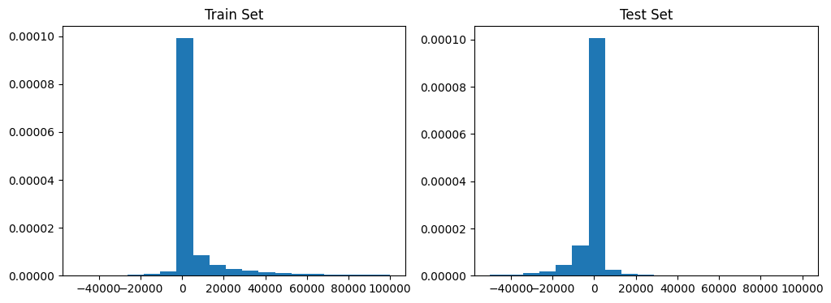

```python
fig, axes = plt.subplots(1, 2, figsize=(12, 4))
axes[0].hist(train['balance'],
         bins=list(np.linspace(-50000, 100000, 20)), density=True)
axes[0].set_title('Train Set')
axes[1].hist(test['balance'],
         bins=list(np.linspace(-50000, 100000, 20)), density=True)
axes[1].set_title('Test Set')
```

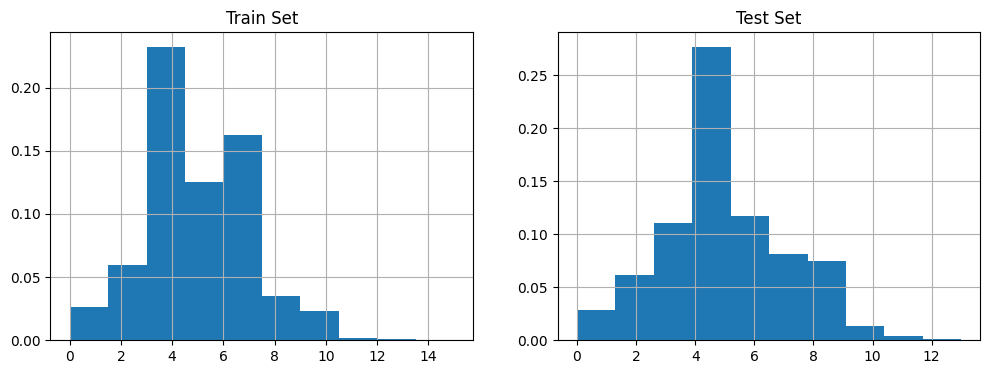

```python
X_train['n_products'] = train[cols[1:18]].apply(sum, axis=1)
X_test['n_products'] = test[cols[1:18]].apply(sum, axis=1)

fig, axes = plt.subplots(1, 2, figsize=(12, 4))
X_train['n_products'].hist(ax = axes[0], density=True)
axes[0].set_title('Train Set')
X_test['n_products'].hist(ax = axes[1], density=True)
axes[1].set_title('Test Set')
```

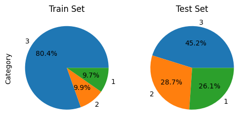

```python
fig, axes = plt.subplots(1, 2, figsize=(6, 4))
train['category'].value_counts().plot.pie(ax = axes[0], autopct='%1.1f%%')
axes[0].set_title('Train Set')
axes[0].set_ylabel('Category')
test['category'].value_counts().plot.pie(ax = axes[1], autopct='%1.1f%%')
axes[1].set_title('Test Set')
axes[1].set_ylabel('')
```

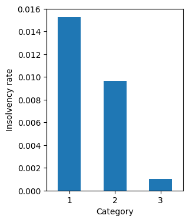

```python
plt.figure(figsize=(3, 4))
train.groupby('category')['repays_debt'].mean().plot(kind='bar')
plt.xticks(rotation=0)
plt.xlabel('Category')
plt.ylabel('Insolvency rate')
```

Costumer's category (firm account, solo proprietorship or private account) is likely to play an important role in the solvency of the debt. Let's go ahead by casting a glance over paired data.

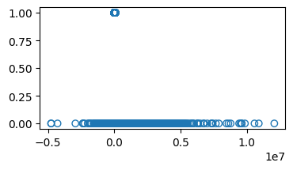

```python
plt.figure(figsize=(4,2))
plt.scatter(train['balance'], train['repays_debt'],
            marker='o', facecolors='none', edgecolors='tab:blue')
```

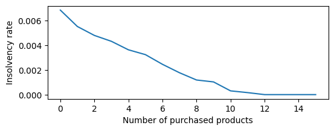

```python
plt.figure(figsize=(6, 2))
X_train.groupby('n_products')['repays_debt'].mean().plot()
plt.xticks(rotation=0)
plt.xlabel('Number of purchased products')
plt.ylabel('Insolvency rate')
```

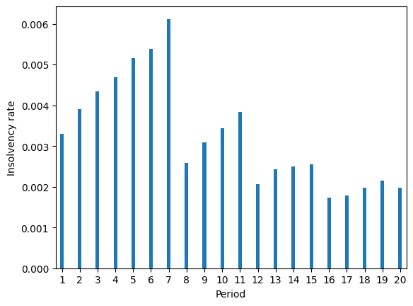

```python
train.groupby('period')['repays_debt'].mean().plot.bar(width=0.2)
plt.xticks(rotation=0)
plt.xlabel('Period')
plt.ylabel('Insolvency rate')
```

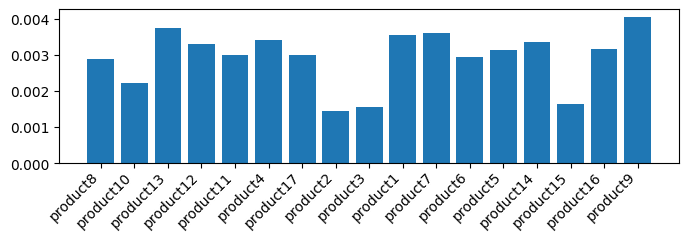

```python
means_by_products = [train.loc[train[cols[i]] == 1].repays_debt.mean()
                     for i in range(1, 18)]
plt.figure(figsize=(8,2))
plt.bar(cols[1:18], means_by_products)
plt.tick_params(axis='x', labelsize=8, pad=1)
plt.xticks(rotation=45, fontsize=10, ha='right')
plt.show()
```

```python
corr_matrix = X_train.corr()
```

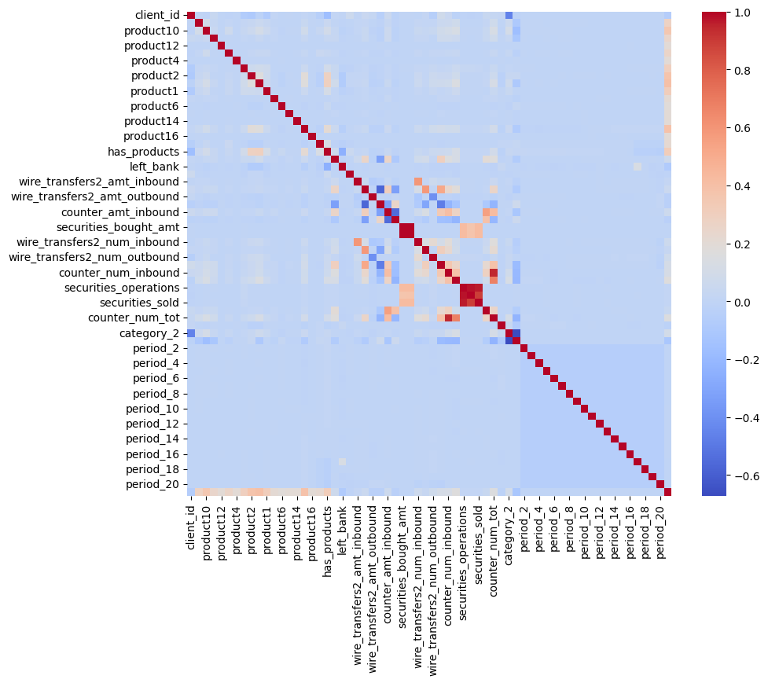

```python
plt.figure(figsize=(10, 8))
sns.heatmap(corr_matrix, cmap='coolwarm',
            cbar=True, square=True)
```

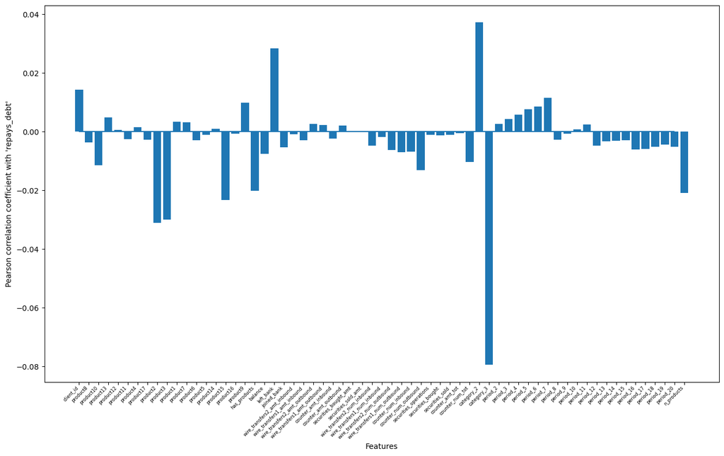

```python
corrs = [np.corrcoef(X_train[col], X_train['repays_debt'])[0, 1]
 for col in X_train.columns if col != 'repays_debt']

plt.figure(figsize = (16, 9))
plt.hlines(0, 0, 61)
plt.bar(X_train.columns.drop(['repays_debt']), corrs)
plt.ylabel("Pearson correlation coefficient with 'repays_debt'")
plt.xlabel("Features")
plt.tick_params(axis='x', labelsize=8, pad=1)
plt.xticks(rotation=45, fontsize=6, ha='right')
plt.show()
```

### Model selection

We are almost done with the preliminaries. For this task we are going to train and evaluate and select the following classification models:

- Logistic Regression
- SVM Classifier
- KNN Classifier
- Random Forest Classifier

Though, we need a resampling of the training set, because it is too large for the training, especially for KNN and RF, and furthermore is too unbalanced in the response columns, with a large proportion of zeroes. Outliers will be either removed or evaluated separately only if necessary.

#### Logistic Regression

First of all `n_products` column we created previously is linear combination of other features, therefore the latter will be removed.

```python
dropped_cols = list(X_train.columns[:18]) + ['repays_debt']
dropped_cols
X_lr = X_train.drop(columns=dropped_cols)
y_lr = X_train['repays_debt']

rus = RandomUnderSampler(random_state=42)

X_under, y_under = rus.fit_resample(X_lr, y_lr)
X_lr_train, X_lr_test, y_lr_train, y_lr_test = train_test_split(X_under, y_under, test_size=.2,stratify=y_under)
```

```python
lr = LogisticRegressionCV()
lr.fit(X_lr_train, y_lr_train)
```

[output not shown]

```
LogisticRegressionCV()
```

```
f1 score: 0.805716492854384
```

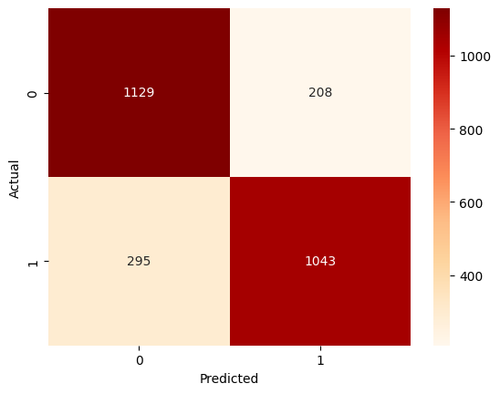

```python
y_lr_pred = lr.predict(X_lr_test)
best_f1_score = f1_score(y_lr_test, y_lr_pred)
print('f1 score:', best_f1_score)
cfm = confusion_matrix(y_lr_test, y_lr_pred)
sns.heatmap(cfm, cmap='OrRd', annot=True, fmt='.0f')
plt.xlabel('Predicted')
plt.ylabel('Actual')
```

We try to remove different features through "backward selection" and validate the results on the test set we previously extracted out of the undersampled train set.

```python
features = list(X_lr_train.columns)
new_best_f1_score = best_f1_score
i = 1
while len(features) > 0 and new_best_f1_score >= best_f1_score:
    print("Iteration n.", i)
    best_f1_score = new_best_f1_score
    worst_feature = None
    for j, feature in enumerate(features):
        lr_tmp = LogisticRegressionCV(verbose=0)
        lr_tmp.fit(X_lr_train[features].drop(columns=feature), y_lr_train)
        y_pred_tmp = lr_tmp.predict(X_lr_test[features].drop(columns=feature))
        tmp_f1_score = f1_score(y_lr_test, y_pred_tmp)
        if tmp_f1_score >= new_best_f1_score or j == 0:
            worst_feature, new_best_f1_score = feature, tmp_f1_score
            print(f"Iteration n. {i}. Without feature '{feature}'"
                  f"-> f1 score = {tmp_f1_score}")
    if worst_feature in features and new_best_f1_score >= best_f1_score:
        features.remove(worst_feature)
    i += 1
```

```python
print(len(features))
np.array(features).tofile('features_lr.txt', sep='\n')
```

```
43
```

```python
X_lr_evaluation = X_test.drop(columns=dropped_cols)
y_lr_evaluation = X_test['repays_debt']

X_lr_submission = X_lr_evaluation.loc[X_test['repays_debt'] == '??']
y_lr_submission = y_lr_evaluation.loc[X_test['repays_debt'] == '??']
X_lr_evaluation = X_lr_evaluation.loc[X_test['repays_debt'] != '??']
y_lr_evaluation = y_lr_evaluation.loc[X_test['repays_debt'] != '??'].astype(int)
```

[output not shown]

```
Classification Report:
               precision    recall  f1-score   support

           0       0.86      0.64      0.73      5054
           1       0.46      0.75      0.57      2118

    accuracy                           0.67      7172
   macro avg       0.66      0.69      0.65      7172
weighted avg       0.74      0.67      0.68      7172
```

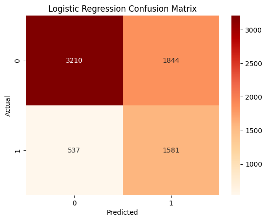

```python
reduced_lr = LogisticRegressionCV()
reduced_lr.fit(X_lr_train[features], y_lr_train)
y_lr_evaluation_pred = reduced_lr.predict(X_lr_evaluation[features])
print(
    "Classification Report:\n",
    classification_report(y_lr_evaluation, y_lr_evaluation_pred)
)
cfm = confusion_matrix(y_lr_evaluation, y_lr_evaluation_pred)
plt.title('Logistic Regression Confusion Matrix')
sns.heatmap(cfm, cmap='OrRd', annot=True, fmt='.0f')
plt.xlabel('Predicted')
plt.ylabel('Actual')
```

```python
y_lr_submission_pred = reduced_lr.predict(X_lr_submission[features])
y_lr_submission_pred.mean()
```

```
0.6100278551532033
```

#### SVM Classifier

We procede similarly for a Support Vector model and for the other models, but from now on we also standardize the data, whereas it was not useful for the binomial glm.

```python
X_svc = X_train.drop(columns=dropped_cols)
y_svc = X_train['repays_debt']

rus = RandomUnderSampler(random_state=42)

X_under, y_under = rus.fit_resample(X_svc, y_svc)
X_svc_train, X_svc_test, y_svc_train, y_svc_test = train_test_split(X_under, y_under, test_size=.2,stratify=y_under)


# -- scaling data -----------------------------------------------------

scaler = StandardScaler()

X_svc_train = pd.DataFrame(scaler.fit_transform(X_svc_train), columns=X_svc.columns)
X_svc_test = pd.DataFrame(scaler.fit_transform(X_svc_test), columns=X_svc.columns)

X_svc_evaluation = pd.DataFrame(scaler.fit_transform(X_test.drop(columns=dropped_cols)), columns=X_svc.columns)
y_svc_evaluation = X_test['repays_debt']

X_svc_submission = pd.DataFrame(scaler.fit_transform(X_svc_evaluation.loc[X_test['repays_debt'] == '??']), columns=X_svc.columns)
y_svc_submission = y_svc_evaluation.loc[X_test['repays_debt'] == '??']
X_svc_evaluation = pd.DataFrame(scaler.fit_transform(X_svc_evaluation.loc[X_test['repays_debt'] != '??']), columns=X_svc.columns)
y_svc_evaluation = y_svc_evaluation.loc[X_test['repays_debt'] != '??'].astype(int)
#---------------------------------------------------------------------------------
```

```python
svc = LinearSVC()
svc.fit(X_svc_train, y_svc_train)
```

```
LinearSVC()
```

```python
y_svc_pred = lr.predict(X_svc_test)
best_f1_score = f1_score(y_svc_test, y_svc_pred)
print('f1 score:', best_f1_score)
# cfm = confusion_matrix(y_lr_test, y_lr_pred)
# print(
#     "Classification Report:\n",
#     classification_report(y_svc_test, y_svc_pred)
# )
# sns.heatmap(cfm, cmap='OrRd', annot=True, fmt='.0f')
# plt.title('SVC Confusion Matrix')
# plt.xlabel('Predicted')
# plt.ylabel('Actual')
```

```
f1 score: 0.7832877782116361
```

```python
# Backward selection

features = list(X_svc_train.columns)
new_best_f1_score = best_f1_score
i = 1
while len(features) > 0 and new_best_f1_score >= best_f1_score:
    print("Iteration n.", i)
    best_f1_score = new_best_f1_score
    worst_feature = None
    for j, feature in enumerate(features):
        svc_tmp = LinearSVC()
        svc_tmp.fit(X_svc_train[features].drop(columns=feature), y_svc_train)
        y_pred_tmp = svc_tmp.predict(X_svc_test[features].drop(columns=feature))
        tmp_f1_score = f1_score(y_svc_test, y_pred_tmp)
        if tmp_f1_score >= new_best_f1_score or j == 0:
            worst_feature, new_best_f1_score = feature, tmp_f1_score
            print(f"Iteration n. {i}. Without feature '{feature}'"
                  f"-> f1 score = {tmp_f1_score}")
    if worst_feature in features and new_best_f1_score >= best_f1_score:
        features.remove(worst_feature)
    i += 1
```

```python
print(len(features))
np.array(features).tofile('features_svc.txt', sep='\n')
```

```
29
```

```
Classification Report:
               precision    recall  f1-score   support

           0       0.85      0.66      0.75      5054
           1       0.47      0.73      0.57      2118

    accuracy                           0.68      7172
   macro avg       0.66      0.69      0.66      7172
weighted avg       0.74      0.68      0.69      7172
```

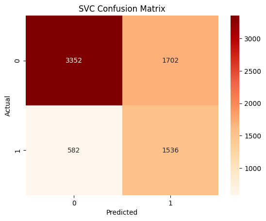

```python
reduced_svc = LinearSVC()
reduced_svc.fit(X_svc_train[features], y_svc_train)
y_svc_evaluation_pred = reduced_svc.predict(X_svc_evaluation[features])
print(
    "Classification Report:\n",
    classification_report(y_svc_evaluation, y_svc_evaluation_pred)
)
cfm = confusion_matrix(y_svc_evaluation, y_svc_evaluation_pred)
plt.title('SVC Confusion Matrix')
sns.heatmap(cfm, cmap='OrRd', annot=True, fmt='.0f')
plt.xlabel('Predicted')
plt.ylabel('Actual')
```

#### KNN Classifier

```python
X_knn = X_train.drop(columns=['client_id', 'repays_debt'])
y_knn = X_train['repays_debt']

rus = RandomUnderSampler(random_state=42)

X_under, y_under = rus.fit_resample(X_knn, y_knn)
X_knn_train, X_knn_test, y_knn_train, y_knn_test = train_test_split(X_under, y_under, test_size=.2,stratify=y_under)


# -- scaling data -----------------------------------------------------

scaler = StandardScaler()

X_knn_train = pd.DataFrame(scaler.fit_transform(X_knn_train), columns=X_knn.columns)
X_knn_test = pd.DataFrame(scaler.fit_transform(X_knn_test), columns=X_knn.columns)

X_knn_evaluation = pd.DataFrame(scaler.fit_transform(X_test[X_knn.columns]), columns=X_knn.columns)
y_knn_evaluation = X_test['repays_debt']

X_knn_submission = pd.DataFrame(scaler.fit_transform(X_knn_evaluation.loc[X_test['repays_debt'] == '??']), columns=X_knn.columns)
y_knn_submission = y_knn_evaluation.loc[X_test['repays_debt'] == '??']
X_knn_evaluation = pd.DataFrame(scaler.fit_transform(X_knn_evaluation.loc[X_test['repays_debt'] != '??']), columns=X_knn.columns)
y_knn_evaluation = y_knn_evaluation.loc[X_test['repays_debt'] != '??'].astype(int)
#---------------------------------------------------------------------------------
```

```python
knn = KNeighborsClassifier(n_neighbors=5)
knn.fit(X_knn_train, y_knn_train)
```

```
KNeighborsClassifier()
```

```python
y_knn_pred = knn.predict(X_knn_test)
best_f1_score = f1_score(y_knn_test, y_knn_pred)
print('f1 score:', best_f1_score)
# cfm = confusion_matrix(y_knn_test, y_knn_pred)
# print(
#     "Classification Report:\n",
#     classification_report(y_knn_test, y_knn_pred)
# )
# sns.heatmap(cfm, cmap='OrRd', annot=True, fmt='.0f')
# plt.title('kNN Confusion Matrix')
# plt.xlabel('Predicted')
# plt.ylabel('Actual')
```

```
f1 score: 0.7656423546834505
```

```python
# Backward selection

features = list(X_knn_train.columns)
new_best_f1_score = best_f1_score
i = 1
while len(features) > 0 and new_best_f1_score >= best_f1_score:
    print("Iteration n.", i)
    best_f1_score = new_best_f1_score
    worst_feature = None
    for j, feature in enumerate(features):
        knn_tmp = KNeighborsClassifier(n_neighbors=5)
        knn_tmp.fit(X_knn_train[features].drop(columns=feature), y_knn_train)
        y_pred_tmp = knn_tmp.predict(X_knn_test[features].drop(columns=feature))
        tmp_f1_score = f1_score(y_knn_test, y_pred_tmp)
        if tmp_f1_score >= new_best_f1_score or j == 0:
            worst_feature, new_best_f1_score = feature, tmp_f1_score
            print(f"Iteration n. {i}. Without feature '{feature}'"
                  f"-> f1 score = {tmp_f1_score}")
    if worst_feature in features and new_best_f1_score >= best_f1_score:
        features.remove(worst_feature)
    i += 1
```

```
Iteration n. 1
Iteration n. 1. Without feature 'product8'-> f1 score = 0.7756906077348066
Iteration n. 1. Without feature 'product13'-> f1 score = 0.7771217712177122
Iteration n. 1. Without feature 'product12'-> f1 score = 0.7774502579218865
Iteration n. 2
Iteration n. 2. Without feature 'product8'-> f1 score = 0.7881918819188192
Iteration n. 3
Iteration n. 3. Without feature 'product10'-> f1 score = 0.7775330396475771
Iteration n. 3. Without feature 'product13'-> f1 score = 0.7851361295069904
Iteration n. 3. Without feature 'product17'-> f1 score = 0.7855297157622739
Iteration n. 3. Without feature 'product1'-> f1 score = 0.7899343544857768
Iteration n. 4
Iteration n. 4. Without feature 'product10'-> f1 score = 0.7922740524781341
Iteration n. 5
Iteration n. 5. Without feature 'product13'-> f1 score = 0.7895310796074155
Iteration n. 5. Without feature 'product11'-> f1 score = 0.7901687454145268
Iteration n. 5. Without feature 'product5'-> f1 score = 0.7906123945727906
Iteration n. 5. Without feature 'product14'-> f1 score = 0.7924253459577567
Iteration n. 5. Without feature 'counter_amt_inbound'-> f1 score = 0.7932920160408312
Iteration n. 5. Without feature 'counter_amt_tot'-> f1 score = 0.7932920160408312
Iteration n. 5. Without feature 'period_2'-> f1 score = 0.7950219619326501
Iteration n. 5. Without feature 'period_16'-> f1 score = 0.7963436928702011
Iteration n. 6
Iteration n. 6. Without feature 'product13'-> f1 score = 0.7928649435748089
Iteration n. 6. Without feature 'balance'-> f1 score = 0.7936857562408223
Iteration n. 6. Without feature 'wire_transfers2_amt_inbound'-> f1 score = 0.7960526315789473
Iteration n. 6. Without feature 'wire_transfers1_amt_inbound'-> f1 score = 0.7963436928702011
Iteration n. 6. Without feature 'wire_transfers2_amt_outbound'-> f1 score = 0.7963436928702011
Iteration n. 6. Without feature 'counter_amt_inbound'-> f1 score = 0.797366495976591
Iteration n. 6. Without feature 'counter_amt_tot'-> f1 score = 0.797366495976591
Iteration n. 7
Iteration n. 7. Without feature 'product13'-> f1 score = 0.7933042212518195
Iteration n. 7. Without feature 'balance'-> f1 score = 0.7948623853211009
Iteration n. 7. Without feature 'wire_transfers2_amt_inbound'-> f1 score = 0.7970749542961609
Iteration n. 7. Without feature 'wire_transfers1_amt_inbound'-> f1 score = 0.797366495976591
Iteration n. 7. Without feature 'wire_transfers2_amt_outbound'-> f1 score = 0.797366495976591
Iteration n. 7. Without feature 'counter_amt_inbound'-> f1 score = 0.7981014968966776
Iteration n. 8
Iteration n. 8. Without feature 'product13'-> f1 score = 0.7918486171761281
Iteration n. 8. Without feature 'balance'-> f1 score = 0.7950128346167951
```

[output cut: 36 more lines]

```
Iteration n. 12. Without feature 'product13'-> f1 score = 0.7918486171761281
Iteration n. 12. Without feature 'balance'-> f1 score = 0.7950128346167951
Iteration n. 12. Without feature 'wire_transfers2_amt_inbound'-> f1 score = 0.7978102189781022
Iteration n. 12. Without feature 'wire_transfers1_amt_inbound'-> f1 score = 0.7981014968966776
Iteration n. 12. Without feature 'wire_transfers2_amt_outbound'-> f1 score = 0.7981014968966776
Iteration n. 13
Iteration n. 13. Without feature 'product13'-> f1 score = 0.7918486171761281
Iteration n. 13. Without feature 'balance'-> f1 score = 0.7950128346167951
Iteration n. 13. Without feature 'wire_transfers2_amt_inbound'-> f1 score = 0.7978102189781022
Iteration n. 13. Without feature 'wire_transfers1_amt_inbound'-> f1 score = 0.7981014968966776
Iteration n. 14
Iteration n. 14. Without feature 'product13'-> f1 score = 0.7921368765926465
Iteration n. 14. Without feature 'balance'-> f1 score = 0.7950128346167951
Iteration n. 14. Without feature 'wire_transfers2_amt_inbound'-> f1 score = 0.7978102189781022
Iteration n. 14. Without feature 'period_12'-> f1 score = 0.7979539641943734
```

```python
print(len(features))
np.array(features).tofile('features_knn.txt', sep='\n')
```

```
49
```

```python
# parameter 'n_neighbors' tuning

for n in range(3,20):
    knn_tmp = KNeighborsClassifier(n_neighbors=n)
    knn_tmp.fit(X_knn_train[features], y_knn_train)
    scores = cross_val_score(knn_tmp, X_knn_train[features], y_knn_train,
                             cv=5, scoring='f1')
    print(f"n_neighbors = {n}: cross-val f1 scores: {scores} (mean = {scores.mean():.3f})")
```

```
n_neighbors = 3: cross-val f1 scores: [0.74104683 0.76049838 0.74187558 0.74728389 0.73471264] (mean = 0.745)
n_neighbors = 4: cross-val f1 scores: [0.71036585 0.72764435 0.7034914  0.72105263 0.70510204] (mean = 0.714)
n_neighbors = 5: cross-val f1 scores: [0.7588717  0.78244804 0.76851421 0.77599244 0.75428043] (mean = 0.768)
n_neighbors = 6: cross-val f1 scores: [0.73932253 0.76892822 0.74962519 0.74300254 0.73410115] (mean = 0.747)
n_neighbors = 7: cross-val f1 scores: [0.76586034 0.79172414 0.77808728 0.78497653 0.76658933] (mean = 0.777)
n_neighbors = 8: cross-val f1 scores: [0.75988428 0.7751938  0.76568627 0.766      0.74498287] (mean = 0.762)
n_neighbors = 9: cross-val f1 scores: [0.78169336 0.79212454 0.78737233 0.78457197 0.77262288] (mean = 0.784)
n_neighbors = 10: cross-val f1 scores: [0.76997113 0.7806049  0.77027683 0.77113198 0.75855422] (mean = 0.770)
n_neighbors = 11: cross-val f1 scores: [0.79212454 0.79559026 0.78591288 0.79063232 0.77413479] (mean = 0.788)
n_neighbors = 12: cross-val f1 scores: [0.78104265 0.78571429 0.77600387 0.77234568 0.77216397] (mean = 0.777)
n_neighbors = 13: cross-val f1 scores: [0.79890561 0.78949793 0.78422274 0.78770686 0.7826484 ] (mean = 0.789)
n_neighbors = 14: cross-val f1 scores: [0.7884797  0.78178368 0.77627772 0.77194703 0.77846009] (mean = 0.779)
n_neighbors = 15: cross-val f1 scores: [0.80018165 0.79207008 0.78731343 0.79849341 0.78229119] (mean = 0.792)
n_neighbors = 16: cross-val f1 scores: [0.79737336 0.78807947 0.7826506  0.78492025 0.78215962] (mean = 0.787)
n_neighbors = 17: cross-val f1 scores: [0.80346557 0.80183486 0.78475128 0.79607109 0.78467153] (mean = 0.794)
n_neighbors = 18: cross-val f1 scores: [0.79850397 0.79584121 0.773549   0.78457831 0.77610536] (mean = 0.786)
n_neighbors = 19: cross-val f1 scores: [0.79981802 0.80183908 0.78418605 0.79512424 0.78300594] (mean = 0.793)
```

```python
# 17 is the best parameter after cross validation in the train set
knn = KNeighborsClassifier(n_neighbors=17)
knn.fit(X_knn_train[features], y_knn_train)
y_knn_pred = knn.predict(X_knn_test[features])
best_f1_score = f1_score(y_knn_test, y_knn_pred)
print('f1 score:', best_f1_score)
```

```
f1 score: 0.8069919883466861
```

```
Classification Report:
               precision    recall  f1-score   support

           0       0.88      0.58      0.70      5054
           1       0.45      0.81      0.58      2118

    accuracy                           0.65      7172
   macro avg       0.66      0.70      0.64      7172
weighted avg       0.75      0.65      0.66      7172
```

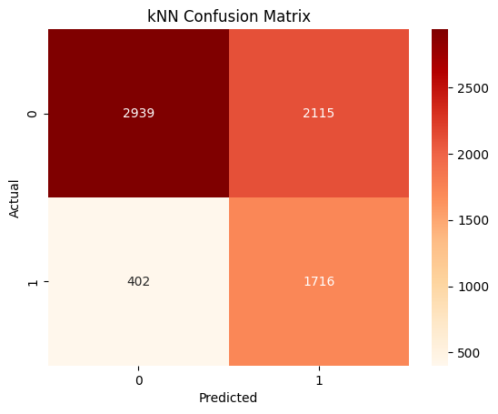

```python
reduced_knn = KNeighborsClassifier(n_neighbors=17)
reduced_knn.fit(X_knn_train[features], y_knn_train)
y_knn_evaluation_pred = reduced_knn.predict(X_knn_evaluation[features])
print(
    "Classification Report:\n",
    classification_report(y_knn_evaluation, y_knn_evaluation_pred)
)
cfm = confusion_matrix(y_knn_evaluation, y_knn_evaluation_pred)
plt.title('kNN Confusion Matrix')
sns.heatmap(cfm, cmap='OrRd', annot=True, fmt='.0f')
plt.xlabel('Predicted')
plt.ylabel('Actual')
```

#### Random Forest

```python
X_rf = X_train.drop(columns=['client_id', 'repays_debt'])
y_rf = X_train['repays_debt']

rus = RandomUnderSampler(random_state=42)

X_under, y_under = rus.fit_resample(X_rf, y_rf)
X_rf_train, X_rf_test, y_rf_train, y_rf_test = train_test_split(X_under, y_under, test_size=.2,stratify=y_under)

X_rf_evaluation = X_test[X_rf.columns]
y_rf_evaluation = X_test['repays_debt']

X_rf_submission = X_rf_evaluation.loc[X_test['repays_debt'] == '??']
y_rf_submission = y_rf_evaluation.loc[X_test['repays_debt'] == '??']
X_rf_evaluation = X_rf_evaluation.loc[X_test['repays_debt'] != '??']
y_rf_evaluation = y_rf_evaluation.loc[X_test['repays_debt'] != '??'].astype(int)
```

```python
rf = RandomForestClassifier(n_estimators=101, random_state=42, n_jobs=-1)
rf.fit(X_rf_train, y_rf_train)
```

```
RandomForestClassifier(n_estimators=101, n_jobs=-1, random_state=42)
```

```python
y_rf_pred = rf.predict(X_rf_test)
best_f1_score = f1_score(y_rf_test, y_rf_pred)
print('f1 score:', best_f1_score)

# cfm = confusion_matrix(y_rf_test, y_rf_pred)
# print(
#     "Classification Report:\n",
#     classification_report(y_rf_test, y_rf_pred)
# )
# sns.heatmap(cfm, cmap='OrRd', annot=True, fmt='.0f')
# plt.title('RF Confusion Matrix')
# plt.xlabel('Predicted')
# plt.ylabel('Actual')
```

```
f1 score: 0.8538812785388128
```

```
Classification Report:
               precision    recall  f1-score   support

           0       0.92      0.90      0.91      5054
           1       0.78      0.82      0.80      2118

    accuracy                           0.88      7172
   macro avg       0.85      0.86      0.86      7172
weighted avg       0.88      0.88      0.88      7172
```

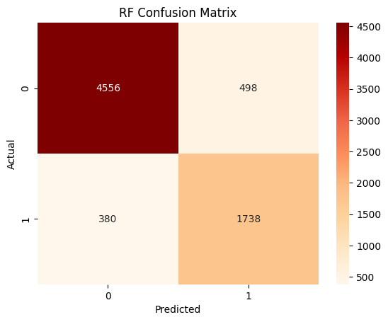

```python
y_rf_evaluation_pred = rf.predict(X_rf_evaluation)
print(
    "Classification Report:\n",
    classification_report(y_rf_evaluation, y_rf_evaluation_pred)
)
cfm = confusion_matrix(y_rf_evaluation, y_rf_evaluation_pred)
plt.title('RF Confusion Matrix')
sns.heatmap(cfm, cmap='OrRd', annot=True, fmt='.0f')
plt.xlabel('Predicted')
plt.ylabel('Actual')
```

#### Ensembled model

Random forest looks the model that gives better results, nevertheless it is good practice to include democratically all the models, through a weighted mean of all predictions.

```python
f1_scores = [
    f1_score(y_lr_test, y_lr_pred),
    f1_score(y_svc_test, y_svc_pred),
    f1_score(y_knn_test, y_knn_pred),
    f1_score(y_rf_test, y_rf_pred)
]

def ensemble(*y_preds, weights: list[float] = 1) -> np.array:
    if isinstance(weights, int):
        weights = np.array([weights]*len(y_preds))
    return (np.column_stack(y_preds) @ weights) / sum(weights)

test_preds = [y_lr_pred, y_svc_pred, y_knn_pred, y_rf_pred]
evaluation_preds = [y_lr_evaluation_pred, y_svc_evaluation_pred,
                    y_knn_evaluation_pred, y_rf_evaluation_pred]
```

```
Classification Report:
               precision    recall  f1-score   support

           0       0.89      0.93      0.91      5054
           1       0.82      0.73      0.77      2118

    accuracy                           0.87      7172
   macro avg       0.86      0.83      0.84      7172
weighted avg       0.87      0.87      0.87      7172
```

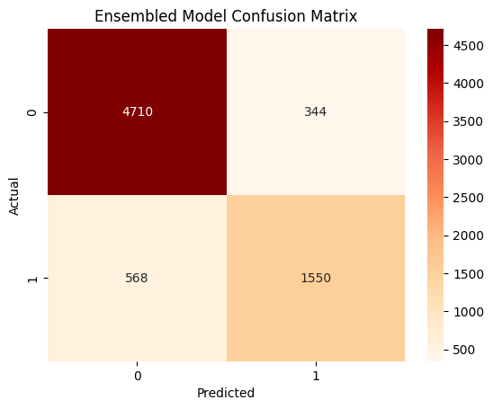

```python
y_evaluation = y_rf_evaluation
# print(pd.DataFrame(
#     {'answer': ensemble(*evaluation_preds, weights=f1_scores)}).value_counts().sort_index())
y_ensemble_evaluation_pred = ensemble(*evaluation_preds, weights=f1_scores) > 0.75
print(
    "Classification Report:\n",
    classification_report(y_evaluation, y_ensemble_evaluation_pred)
)
cfm = confusion_matrix(y_evaluation, y_ensemble_evaluation_pred)
plt.title('Ensembled Model Confusion Matrix')
sns.heatmap(cfm, cmap='OrRd', annot=True, fmt='.0f')
plt.xlabel('Predicted')
plt.ylabel('Actual')
```

we claim a costumer to be in the class '1' when all four models give that outcome, with pseudo-random exceptions of three voting models due to numerical machine calculation approximations (this is a very rough, yet deliberate approach). This choice drops dramatically the False positive rate, but tends to increase the number of false negatives.